# Guided Exercise 09 - Classification

The goal of this exercise is to practice with metrics of classifier performance.

## Getting started

We’ll start today with an interactive activity.

> [Attacking discrimination with smarter machine learning](http://research.google.com/bigpicture/attacking-discrimination-in-ml/)

We’ll focus today on the one-group example; we’ll return to the part about blue vs orange groups later.

### Explore

Spend about 10 minutes playing with the “Threshold Decision” demonstration. Discuss the following questions with your partner:

1. What are the “scores”? What real-life concept does this capture? (Do you know your score?)
2. Why might a bank want to use “score” to decide whether to grant a loan? (Why don’t banks grant all loan applications? Why do they ever grant loans?)
3. What sort of predictions are being made here? What constitutes a “correct” prediction?
4. Slowly sweep the threshold from 0 to 100. On scrap paper, sketch how Correct, True Positive Rate, and Positive Rate change as the threshold changes.

### Implement

Now let’s implement those metrics ourselves to check our understanding.

```r
set.seed(0)
make_group_rand <- function(n, mean, sd, ...) {
  tibble(score = rnorm(n, mean = mean, sd = sd), ...)
}

# "Deterministic normal": for n points, we expect n * pnorm(x, mu, sd) of them to be below x.
make_group <- function(n, mean, sd, ...) {
  tibble(score = 0:100) %>%
    mutate(n = floor(n * pnorm(score, mean, sd))) %>%
    mutate(delta = c(diff(n), 0)) %>%
    uncount(delta) %>%
    select(score) %>%
    mutate(...)
}

people <- bind_rows(
  make_group(150, 60, 10, repay = TRUE),
  make_group(150, 40, 10, repay = FALSE)
)
```

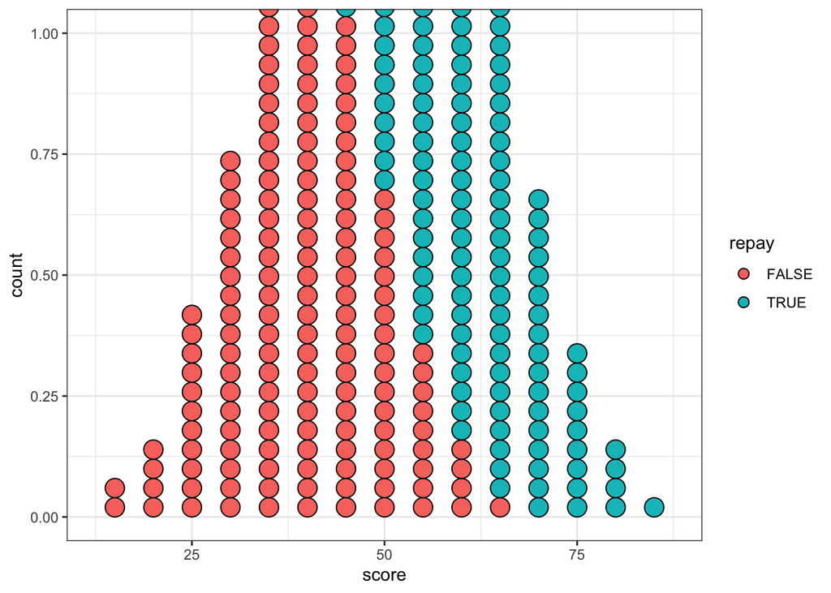

```r
ggplot(people, aes(x = score, fill = repay)) +
  geom_dotplot(binwidth = 5, dotsize = .5, binpositions = "all", method = "histodot", stackgroups = TRUE)
```

In your RStudio, find `ex09-classification.Rmd` and Run All. Look at the `people` data frame and make sure you understand what it is and how it relates to the data in the web demonstration.

Also, study the following to understand how it works:

```r
people %>%
  summarize(num_repayed = sum(repay),
            frac_repayed = mean(repay))
```

```
# A tibble: 1 × 2
  num_repayed frac_repayed
        <int>        <dbl>
1         149          0.5
```

1. Add a new column, `granted`, to the `people` dataframe that indicates if the bank grants the loan. Like the website, grant a loan if the score exceeds some fixed `threshold`. (Use a threshold that results in all 4 colors being visible; it’s especially visible in the Positive Rate pie.) Save the results in `decisions`.
2. Compute the Positive Rate and the True Positive Rate, and Correctness. (Use `summarize` and perhaps `filter` on the `decisions`.) Check all of your results against the webapp; the numbers should be close although they may differ slightly because the data was not constructed identically.
3. Compute the sensitivity and specificity. You may consult the [Wikipedia Page](https://en.wikipedia.org/wiki/Sensitivity_and_specificity#Confusion_matrix) if it’s helpful. (Have you already computed one of these?) Discuss with your partner what “sensitivity” and “specificity” mean in this scenario.
4. Add a column to `decisions` called `outcome` that gives a label to each decision as a “True Positive”, “False Positive”, etc. Use `case_when` with conditions like `repay & !granted`. Count how many of each outcome occurs at your current threshold.
5. Adjust the `threshold` to maximize the Correct rate. What is the True Positive Rate then? What trade-off do we have to make if we want to maximize True Positive Rate instead?
6. *bonus*: Create the following plot. You will need `expand_grid(threshold = 1:100)`.

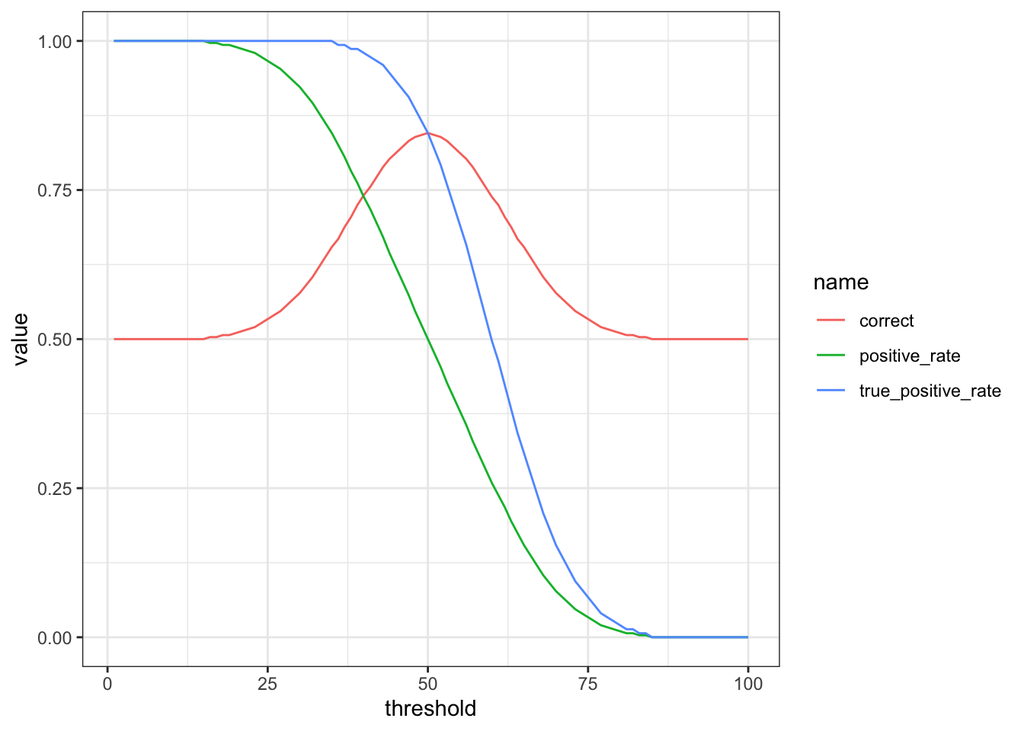